# What pathways are captured in models trained on different biological contexts?

**J. Taroni 2018**

A pathway will be considered captured or represented when training on a particular biological context if the majority of models have at least one latent variable significantly associated (we’ll use `FDR < 0.05`) with it. We have trained 5 models initialized with different random seeds for each biological context (identical training set). Thus, if 3 or more models have a latent variable associated with a pathway, that pathway is to be considered captured in that biological context.

## Set up

```r
# magrittr pipe
`%>%` <- dplyr::`%>%`
```

```r
GetRepresentedPathways <- function(list.of.plier.models, fdr.cutoff = 0.05) {
  # For a list of plier models (e.g., series of repeats; output of
  # scripts/subsampling_PLIER.R), find what pathways are represented in a
  # majority of those models.
  #
  # Args:
  #   list.of.plier.models: the list of results
  #   fdr.cutoff: what FDR threshold should be used to determine if a pathway
  #               is captured? default is 0.05
  #
  # Returns:
  #   a vector of pathway names

  # what pathways have at least one LV with FDR < fdr.cutoff
  IdentifyCapturedPathways <- function(plier.results) {
    summary.df <- plier.results$summary
    captured.pathways <-
      unique(summary.df$pathway[which(summary.df$FDR < fdr.cutoff)])
  }

  # for each model (repeat) in the list, what pathways are captured?
  captured.pathways.list <-
    lapply(list.of.plier.models, function(x) IdentifyCapturedPathways(x$PLIER))

  # get counts
  count.table <- table(unlist(captured.pathways.list))
  # which pathways are represented in the majority of models?
  number.of.models <- length(list.of.plier.models)
  majority.number <- ceiling(number.of.models / 2)
  majority.pathways <- names(count.table[which(count.table >= majority.number)])

  # return the list of pathways represented in the majority of models
  return(majority.pathways)

}
```

#### Directories

Plot and results directories specifically for this notebook.

```r
# plot and result directory setup for this notebook
plot.dir <- file.path("plots", "33")
dir.create(plot.dir, recursive = TRUE, showWarnings = FALSE)
results.dir <- file.path("results", "33")
dir.create(results.dir, recursive = TRUE, showWarnings = FALSE)
```

We’re interested in the models exploring the different biological contexts, not the various sample sizes.

```r
models.dir <- "models"
# can be distinguished by the file names
model.files <- list.files(models.dir, pattern = "accessions", full.names = TRUE)
```

## Identify the represented pathways

```r
pathway.lists <- lapply(model.files, function(x) {
    model.list <- readRDS(x)
    GetRepresentedPathways(model.list)
  })
names(pathway.lists) <- stringr::str_match(model.files,
                                           "recount2_(.*?)_accessions")[, 2]
```

Let’s make an [UpSet plot](https://caleydo.org/tools/upset/) examining the overlap between the five biological conditions.

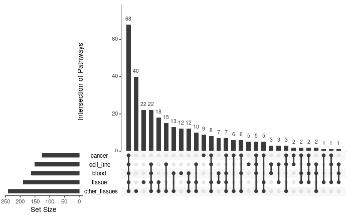

```r
UpSetR::upset(UpSetR::fromList(pathway.lists),
              order.by = "freq",
              point.size = 2, line.size = 1,
              mainbar.y.label = "Intersection of Pathways",
              text.scale = 1.25)
```

Save the plot to file

```r
pdf(file.path(plot.dir, "biological_context_upset.pdf"))
UpSetR::upset(UpSetR::fromList(pathway.lists),
              order.by = "freq",
              point.size = 2, line.size = 1,
              mainbar.y.label = "Intersection of Pathways",
              text.scale = 1.25)
dev.off()
```

We can use `VennDiagram::calculate.overlap` to find which pathways are overlapping and use the intersection size above to help us figure things out from there.

```r
overlaps.list <- VennDiagram::calculate.overlap(pathway.lists)
```

### Blood

Let’s take a look at what is captured exclusively in the models trained on blood.

```r
data.frame(overlaps.list$a1)
```

| overlaps.list.a1 |
| --- |
| BIOCARTA_RHO_PATHWAY |
| DMAP_BCELLA2 |
| DMAP_BCELLA3 |
| DMAP_DENDA1 |
| DMAP_TCELLA8 |
| IRIS_CD4Tcell-Th1-restimulated12hour |
| IRIS_MemoryTcell-RO-unactivated |
| KEGG_AMINO_SUGAR_AND_NUCLEOTIDE_SUGAR_METABOLISM |
| KEGG_P53_SIGNALING_PATHWAY |
| KEGG_SNARE_INTERACTIONS_IN_VESICULAR_TRANSPORT |

[output cut: 2 more lines]

We can see that half of these are immune cell-related genesets. Specifically, the `DMAP` gene sets are further differentiated cell types (see [Figure 1](https://www.ncbi.nlm.nih.gov/pmc/articles/PMC3049864/figure/F1/) of [Novershtern, et al. *Cell.* 2011.](https://doi.org/10.1016%2Fj.cell.2011.01.004))

### Everything but cancer

If we look at the UpSet plot above, we can see that the largest set of in-all-but-one is excluding cancer with 22 pathways.

What are the pathways that are left out of the cancer models?

```r
data.frame(overlaps.list$a27)
```

| overlaps.list.a27 |
| --- |
| DMAP_GRAN2 |
| DMAP_MONO2 |
| DMAP_NKA1 |
| DMAP_NKA2 |
| DMAP_NKA3 |
| DMAP_TCELLA6 |
| IRIS_Monocyte-Day1 |
| IRIS_Monocyte-Day7 |
| IRIS_PlasmaCell-FromPBMC |
| KEGG_DNA_REPLICATION |

[output cut: 12 more lines]

We can see that natural killer (NK) cells are represented in other models, but less so in cancer (e.g., `DMAP_NKA1` and `SVM NK cells activated`).

We’d likely expect models that are trained on blood to be particularly good at capturing NK cell signals despite their relatively small sample size (`n = 3862`).

It could be that the cancer sample size (`n = 8807`) is just too small to adequately capture this signal. We trained models on 8000 randomly selected samples, so we can use those models to look into this.

```r
eight.thousand.file <- file.path(models.dir,
                                 "subsampled_recount2_PLIER_model_8000.RDS")
eight.thousand.list <- readRDS(eight.thousand.file)
```

What pathways are in the majority of models (`n = 8000`, randomly selected)?

```r
eight.thousand.pathways <- GetRepresentedPathways(eight.thousand.list)
```

Are NK cells covered?

```r
data.frame(eight.thousand.pathways[grep("NK", eight.thousand.pathways)])
```

| eight.thousand.pathways.grep..NK...eight.thousand.pathways.. |
| --- |
| DMAP_NKA1 |
| DMAP_NKA2 |
| DMAP_NKA3 |
| IRIS_NKcell-control |
| REACTOME_ASPARAGINE_N_LINKED_GLYCOSYLATION |
| SVM NK cells activated |
| SVM NK cells resting |

This underrepresentation in cancer models may be due to the sometimes immunosuppressive nature of the tumor microenvironment. However, this analysis doesn’t specifically examine the *quality or usefulness* of the NK cell gene set-latent variable association (i.e., is the latent variable associated with many, unrelated pathways?).